# Time Series Models Simulation Notebook

There are two simulation provided in this notebook (1) Random walk (2) Moving average with Lag 2

The ACF function tell us the autocorrelation. Whenever we have a time series to analyze, we remove the overall trend and seasonality trend, and then apply the time series model on it provided we have stationary time series.

Here is correlogram of ACF function for a simple white noise (~(iid) Normal(0,1)) looks like.

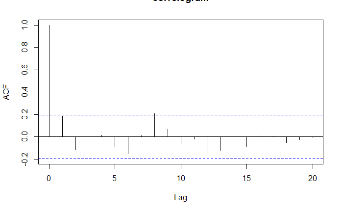

```r
noise_ts =  ts(rnorm(100))
acf(noise_ts,main="correlogram",)
```

Now let us simulate a Random walk. Def: A random walk model is a time series model where X_t = X_t-1 + Z_t where Zt is white noise ~ Normal(mean,std^2).

Let us assume our X0 is 0, then X1 becomes Z1, X2 = X1 + Z2 = Z1 + Z2 and so on

Xt = sum of all Z E[Xt] = mean * t V[Xt] = std^2 * t

Note the mean and variance are both dependent on t so it is not a stationary time series. Let check this :

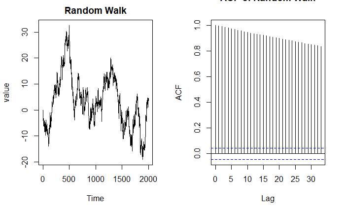

```r
#Init
z = rnorm(2000)
x=NULL
x[1] = 0
for(i in 2:2000){
  x[i] =  z[i] + x[i-1]
}
#Convert to ts
random_walk_ts =  ts(x)
par(mfrow=c(1,2))
plot(random_walk_ts,main='Random Walk',ylab = 'value')
acf(random_walk_ts,main='ACF of Random Walk')
```

From the ACF plot it is clear that it is surely not a stationary time series. One thing to note is that we can actually convert a random walk into a time series by application of a difference operator because Xt = Xt-1 + Zt if I subract the lagged series (by -1) then Xt = Zt. Thus we obtain a purely stocastic process.

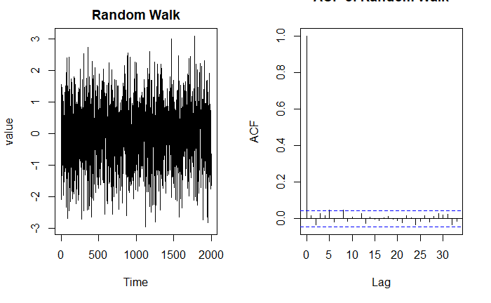

```r
#one way
random_walk_ts_lagged = lag(random_walk_ts,-1)
new_random_ts = random_walk_ts - random_walk_ts_lagged
#Another way
n_rand_ts = diff(random_walk_ts)
par(mfrow=c(1,2))
plot(new_random_ts,main='Random Walk',ylab = 'value')
acf(new_random_ts,main='ACF of Random Walk')
```

Now, lets shift our focus to Moving average. Moving average is a time series model in which Xt is a linear combination of previous noise value. i.e. MA(k) model is a linear combination of k past (from t to t-k) random noise.

Example for MA(2) X_t = z_t + a1 X Z_(t-1) + a2 X Z_(t-2) where Zt is iid white noise. Lets simulate the MA(2) process

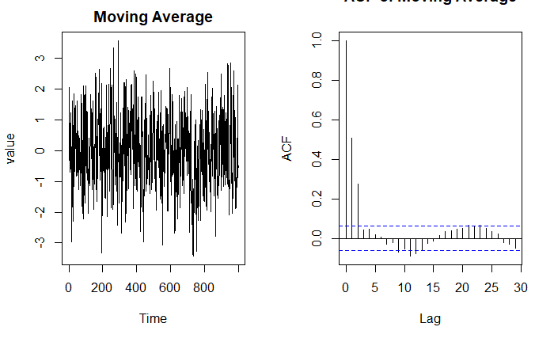

```r
z = rnorm(1000)
ma_2 = NULL
for(i in 3:1000){
  ma_2[i] = z[i] + 0.5*z[i-1] + 0.3 * z[i-2]
}
movingAverage_TS = ts(ma_2[3:1000])
par(mfrow=c(1,2))
plot(movingAverage_TS,main='Moving Average',ylab = 'value')
acf(movingAverage_TS,main='ACF of Moving Average')
```